# Egzaminas

Greta Sakalauskaitė, 1811320

2019-06-20 12:04

# 1 Prieš pradedant

- Ant desktopo sukurkite direktoriją “exam”, į ją išsaugokite šį dokumentą pakeisdami jo pavadinimą į “StudNr_Vardas_Pavarde.Rmd” (nenaudokite lt rašmenų) bei atitinkamai pakeisdami viršuje esančius laukelius: “author: …”
- Sumegzkite iškart šį dokumentą į .html failą ir įsitikinkite, jog viskas veikia gerai, tik tada pradėkite spręsti uždavinius.

# 2 Pasiruošimas

Šioje kodo dalyje surašykite visus paskesnėse dalyse naudojamus R paketus. Kodas turi patikrinti, ar paketas yra instaliuotas, jeigu ne, instaliuoti bei užloadinti. Jeigu darbo eigoje prireikia naujų paketų, nepamirkite čia juos įrašyti.

```r
if (!require(tidyverse)) install.packages("tidyverse"); require(tidyverse)
if (!require(eurostat)) install.packages("eurostat"); require(eurostat)
if (!require(reshape2)) install.packages("reshape2"); require(reshape2)
if (!require(knitr)) install.packages("knitr"); require(knitr)
```

# 3 Istorija

Šiuo metu Jūs darbuojatės NVO “Stop skurdas”. Koks tai “influenceris” patrolino visuomenę (galimai apmokėtas privačių pensijų fondų), jog Sodroje kaupti pensijai neapsimoka ir kaip pvz. pateikė savo mamulę, gaunančią vos 221 eurą per mėnesį. https://i1.wp.com/lithuanian-economy.net/wp-content/uploads/2019/06/Saugirdas.jpg

Komentaruose pasipylė aibė pasisakymų, jog jeigu neturėtume “pašalpinių” armijos ir jiems skirtus pinigus skirtume pensininkams, tai pensininkai gyventų “oriau”.

Jums tokie argumentai sukelia daug abejonių. Kadangi Jūs kažkaip išgyvenote duomenų analizės įvadą, Jūs nusprendžiate pateikti tam tikrus faktus viešai diskusijai. Šių faktų generavimas ir yra Jūsų egzamino užduotis.

## 3.1 Duomenų importas

Importuokite duomenis iš eurostat apie tai, kiek Lietuva (visas valdžios sektorius) ir ES-28 skiria % BVP socialinei paramai. Kadangi datasetas yra didelis, rekomenduoju parsisiųsti tik reikalingus duomenis.

[Pagalba: “gov_10a_exp”, reikalingos išlaidų rūšys “Social protection”, “Old age”, “Sickness and disability”]

```r
gov_10a_exp <- get_eurostat("gov_10a_exp", stringsAsFactors = FALSE)

df1 <- gov_10a_exp %>% filter(cofog99=="GF10"|
                              cofog99=="GF1001"|
                               cofog99=="GF1002",
                              geo=="LT"|
                              geo=="EU28",
                             unit=="PC_GDP",
                             na_item=="TE",
                             sector=="S13")
```

## 3.2 Duomenų apdorojimas

Kadangi “pašalpiniai” gauna įvairią socialinę pagalbą (pvz., lengvatas būsto šildymui, vaikų maitinimui mokykloje ir t.t.), šioje dalyje pabandysime iš visų išlaidų socialinei apsaugai atimti pensijas ir ligos pašalpas, o likutį pavadinsime `pasalpa`.

Sukurkite nauja dataframe objektą, kuriame būtų LT ir EU28 laiko eilutės (nuo 2004 metų) su 2 išlaidų sritimis: pasalpa (kurią apskaičiavote) bei išlaidomis pensijoms.

```r
df2 <- df1 %>% filter(time>="2004-01-01")%>%
  group_by(time,geo,cofog99) %>%
  summarise(viso = sum(values))

#pasalpa=df2$viso-(df1$cofog99"GF10"+df1$cofog99"GF1001"
```

## 3.3 Nubraižykite grafiką

- Nubraižykite prieš tai žingsnyje apdorotus duomenis linijine diagrama su taškais (shape)
- Spalvą priskirkite geo
- Taškų (shape) formą priskirkite išlaidų rūšims.
- Tikėtina Jums reikės googlinti arba ieškoti stackoverflow, kaip pranešti ggplot2, kaip yra sugrupuoti duomenys (jeigu norite jog visos 4 linijos būtų viename grafike), alternatyviai galite skaidyti grafiką į dvi dalis, pagal išlaidų rūšis (tada skaidymas turi vykti naudojant vieną iš ggplot2 komandų)
- Nepamirškite tvarkingo apipavidalinimo (ašys, antraštės ir t.t.)

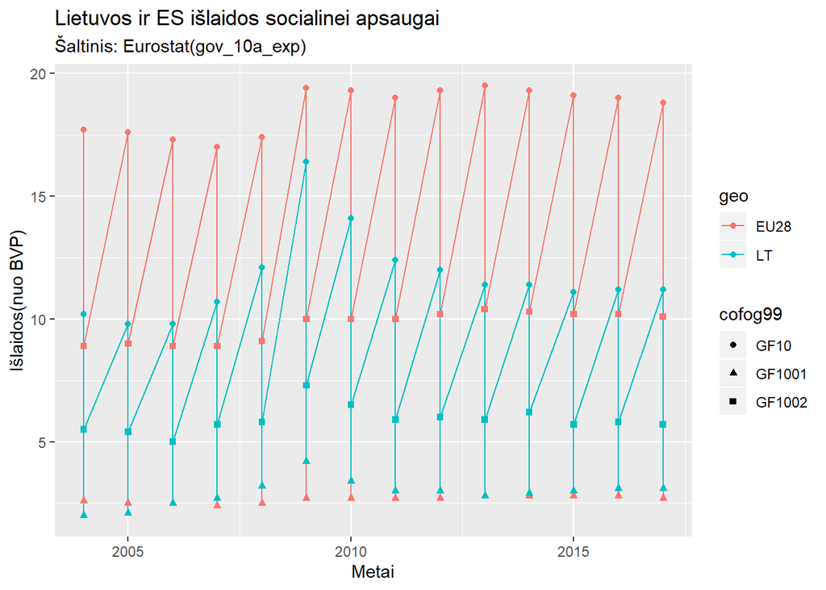

```r
ggplot(df2, aes(time,viso, col=geo))+
  geom_line()+
  geom_point(aes(shape=cofog99))+
  labs(title = "Lietuvos ir ES išlaidos socialinei apsaugai",
       subtitle = "Šaltinis: Eurostat(gov_10a_exp)",
       x = "Metai",
       y = "Išlaidos(nuo BVP)")
```

## 3.4 Apskaičiuokite

- ES28 išlaidos % BVP
- LT išlaidos % BVP
- skirtumas procentiniais punktais (primenu, 1.9%-1.5%=0.4 proc.punkto)
- trečio stulpelio reikšmes sudauginkite su Lietuvos 2017m BVP (= 41857 mln eur), nes norite žinoti, kiek mln eurų reiktų skirti šioms sritims, tam kad pasiektume ES vidurkį
- PERSPĖJIMAS: kai skaičiuosite reikalingas lėšas, pasitikrinkite, ar teisingai skaičiuojate kai sudauginate su proc. punktais! :)

```r
kable(df1)
```

| unit | sector | cofog99 | na_item | geo | time | values |
| --- | --- | --- | --- | --- | --- | --- |
| PC_GDP | S13 | GF10 | TE | EU28 | 2017-01-01 | 18.8 |
| PC_GDP | S13 | GF10 | TE | LT | 2017-01-01 | 11.2 |
| PC_GDP | S13 | GF1001 | TE | EU28 | 2017-01-01 | 2.7 |
| PC_GDP | S13 | GF1001 | TE | LT | 2017-01-01 | 3.1 |
| PC_GDP | S13 | GF1002 | TE | EU28 | 2017-01-01 | 10.1 |
| PC_GDP | S13 | GF1002 | TE | LT | 2017-01-01 | 5.7 |
| PC_GDP | S13 | GF10 | TE | EU28 | 2016-01-01 | 19.0 |
| PC_GDP | S13 | GF10 | TE | LT | 2016-01-01 | 11.2 |
| PC_GDP | S13 | GF1001 | TE | EU28 | 2016-01-01 | 2.8 |
| PC_GDP | S13 | GF1001 | TE | LT | 2016-01-01 | 3.1 |
| PC_GDP | S13 | GF1002 | TE | EU28 | 2016-01-01 | 10.2 |
| PC_GDP | S13 | GF1002 | TE | LT | 2016-01-01 | 5.8 |
| PC_GDP | S13 | GF10 | TE | EU28 | 2015-01-01 | 19.1 |
| PC_GDP | S13 | GF10 | TE | LT | 2015-01-01 | 11.1 |
| PC_GDP | S13 | GF1001 | TE | EU28 | 2015-01-01 | 2.8 |
| PC_GDP | S13 | GF1001 | TE | LT | 2015-01-01 | 3.0 |
| PC_GDP | S13 | GF1002 | TE | EU28 | 2015-01-01 | 10.2 |
| PC_GDP | S13 | GF1002 | TE | LT | 2015-01-01 | 5.7 |
| PC_GDP | S13 | GF10 | TE | EU28 | 2014-01-01 | 19.3 |
| PC_GDP | S13 | GF10 | TE | LT | 2014-01-01 | 11.4 |
| PC_GDP | S13 | GF1001 | TE | EU28 | 2014-01-01 | 2.8 |
| PC_GDP | S13 | GF1001 | TE | LT | 2014-01-01 | 2.9 |
| PC_GDP | S13 | GF1002 | TE | EU28 | 2014-01-01 | 10.3 |
| PC_GDP | S13 | GF1002 | TE | LT | 2014-01-01 | 6.2 |
| PC_GDP | S13 | GF10 | TE | EU28 | 2013-01-01 | 19.5 |
| PC_GDP | S13 | GF10 | TE | LT | 2013-01-01 | 11.4 |
| PC_GDP | S13 | GF1001 | TE | EU28 | 2013-01-01 | 2.8 |
| PC_GDP | S13 | GF1001 | TE | LT | 2013-01-01 | 2.8 |
| PC_GDP | S13 | GF1002 | TE | EU28 | 2013-01-01 | 10.4 |
| PC_GDP | S13 | GF1002 | TE | LT | 2013-01-01 | 5.9 |

[output cut: 74 more lines]

## 3.5 Grafikas 2

Pastebėję, jog socialinės išlaidos pakankamai skiriasi tarp LT is ES28, Jūs nusprendėte nubraižyti stulpelinį grafiką, kuriame būtų pavaizduotos visų ES (t.y. 28!) šalių išlaidos socialiniai sričiai bendrai (“Social protection”) % nuo BVP. Naudokite 2017 metų rodiklius. Tam jog matytųsi ES28 vidurkis nubraižykite jį į grafiką kaip horizontalią liniją.

Jums gali reikėti atsisiųsti reikiamą Eurostat dataset iš naujo. Stulpeliai turėtų būti surikiuoti didėjančia tvarka, jų viršuje pateikiamos stulpelių reikšmės.

Grafikas turėtų atrodyti daugmaž taip: https://i2.wp.com/lithuanian-economy.net/wp-content/uploads/2019/03/private_expenditue_MTEP_2017.jpeg?resize=768%2C427

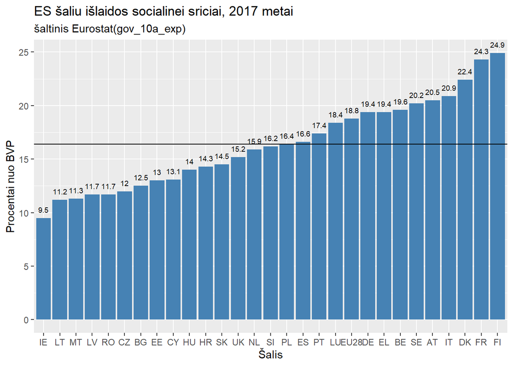

```r
df3 <- gov_10a_exp %>% filter(!(geo %in% c("CH", "NO","IS","EU27","EU25","EU15","EA19","EA18","EA17","EA16","EA15","EA13","EA12","EA11")),cofog99=="GF10", time=="2017-01-01",unit=="PC_GDP",
                             na_item=="TE",
                             sector=="S13")

ggplot(df3, aes(x=reorder(geo,values), values))+
  geom_bar(stat="identity",
           fill="steelblue")+
  geom_text(aes(label=values), size=2.5,hjust=0.5, vjust=-1)+
  labs(title="ES šalių išlaidos socialinei sričiai, 2017 metai",
       subtitle="šaltinis Eurostat(gov_10a_exp)",
       x="Šalis",
       y="Procentai nuo BVP")+
  geom_hline(yintercept =mean(df3$values), color="black")
```

## 3.6 Vertinimas

Pateikite trumpą situacijos vertinimą remiantis iki šiol atlikta duomenų analizę. Pateikite savo įžvalgas, kaip būtų galima spręsti žemų pensijų problemas ateityje. Drąsiai galite remtis Europos Komisijos ataskaita bei rekomendacijomis Lietuvai.

- Rekomendacija: https://ec.europa.eu/info/sites/info/files/file_import/2019-european-semester-country-specific-recommendation-commission-recommendation-lithuania_en.pdf
- Ataskaita : https://ec.europa.eu/info/sites/info/files/file_import/2019-european-semester-country-report-lithuania_lt.pdf

```r
#Parašykite apie 200 (+- 20) žodžių.
#Rašykite VIETOJ Lore ipsum... teksto t.y. tarpe tarp abiejų kabučių.
#Jeigu norite žinoti kiek žodžių parašėte, galite runninti tik šit snippet' jo kampytyje nuspaudę ant žalio trikampio rodančio į dešinę

str1 <-
"
Socialinės apsaugos sritis Lietuvoje patiria labai daug problemų. Ypač didelius sunkumus patiria pensininkai. Mano nuomone, mažų pensijų problemą būtų galima mažinti padidinus finansavimą socialinei sričiai. Kaip matome iš antrojo grafiko, Lietuva socialinei apsaugai skiria tik 11,2% nuo savo Bendrojo vidaus produkto, o šis skaičius yra antras pagal mažumą Europos Sąjungoje (už Lietuvą mažiau socialinei apsaugai skiria tik Airija). Todėl, manau, kad skirdami didesnį finansavimą socialinės apsaugos sričiai, didesnę dalį pinigų būtų galima skirti ir Lietuvos žmonių pensijoms. Tačiau nepritariu teiginiui, jog pašalpų mažinimas yra gera idėja didinti pensijas Lietuvoje. Europos Sąjungos šalys 2017 metais vidutiniškai skyrė apie 32 procentus savo socialinei apsaugai skirtų pinigų pašalpoms. Tuo metu Lietuvoje 2017 metais pašalpoms buvo skirta maždaug 21 procentas nuo socialinei apsaugai skirtų pinigų. Taigi, jeigu dar labiau mažintume šį procentą, skurdo lygis, tarp tų žmonių, kurie gauna pašalpas, didėtų, o to pasekoje didėtų ir pajamų nelygybė. Vietoj to, manau būtų verta, skatinti žmones, jog jie savo pensijomis pradėtų rūpintis nuo ko ankstensio amžiaus, pradėtų domėtis, kokie yra pensijos kaupimo privačiame pensijų fonde privalumai bei trūkumai, o viską pasvėrus pasirinktų optimalų pensijos kaupimo būdą ir pradėtų kaupti savo pensijai kuo anksčiau.




"
sapply(strsplit(str1," "),length)
```

```
## [1] 189
```

## 3.7 Darbo užbaigimo ir ship’inimo instrukcija:

- Sumegzkite šį dokumentą į `html`, jeigu Jūsų kode yra klaidų ir sumezgimas neveikia, išsaugokite šį failą tiesiog “File -> save”
- Savo Github paskyroje sukurkite repo “exam”
- Pushinkit lokalią repo į Github. Direktorijoje turi būti 2 failai: “StudNr_Vardas_Pavardė.Rmd” ir “StudNr_Vardas_Pavardė.html”
- Įsitikinkite jog Githube guli repo kopija ir repo url įrašykite į google docs J stulpelį: https://docs.google.com/spreadsheets/d/1H_ts3wTKYZ4rocmFseR2YJtZHfhJ543MUWsTTa7x5Kc/edit?usp=sharing